# reproducibility

Enrique Macip Belmonte

## Introducción

El segundo dataset `airquality` contienen datos sobre la calidad del aire de Mayo a Septiembre de 1973 en la ciudad de Nueva York.

## Preparación del ejercicio

Para realizar el ejercicio, se utilizarán las librerías `dplyr`, `tidyr` y `ggplot2`. Para el ejercicio 2, se recomienda utilizar la librería `cowplot`. **Intentar utilizar el operador %>% (*forward pipe*)**.

## Ejercicio 1

Comprobar que tipo de datos tiene el conjunto de elementos proporcionado mediante la función “head”.

```r
head(cars)
```

```
##   speed dist
## 1     4    2
## 2     4   10
## 3     7    4
## 4     7   22
## 5     8   16
## 6     9   10
```

Realizar un resumen para obtener información detalla del conjunto de elementos mediante la función “summary”.

```r
summary(cars)
```

```
##      speed           dist
##  Min.   : 4.0   Min.   :  2.00
##  1st Qu.:12.0   1st Qu.: 26.00
##  Median :15.0   Median : 36.00
##  Mean   :15.4   Mean   : 42.98
##  3rd Qu.:19.0   3rd Qu.: 56.00
##  Max.   :25.0   Max.   :120.00
```

Dibujar mediante un gráfico de puntos (scatterplot) la información contenida (mediante “plot”).

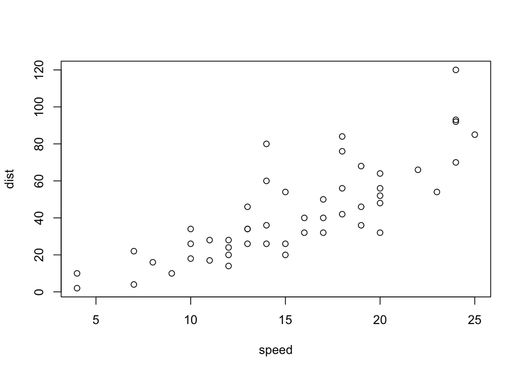

```r
plot(cars)
```

Dibujar mediante un gráfico de puntos (scatterplot) la información contenida (mediante “ggplot2”).

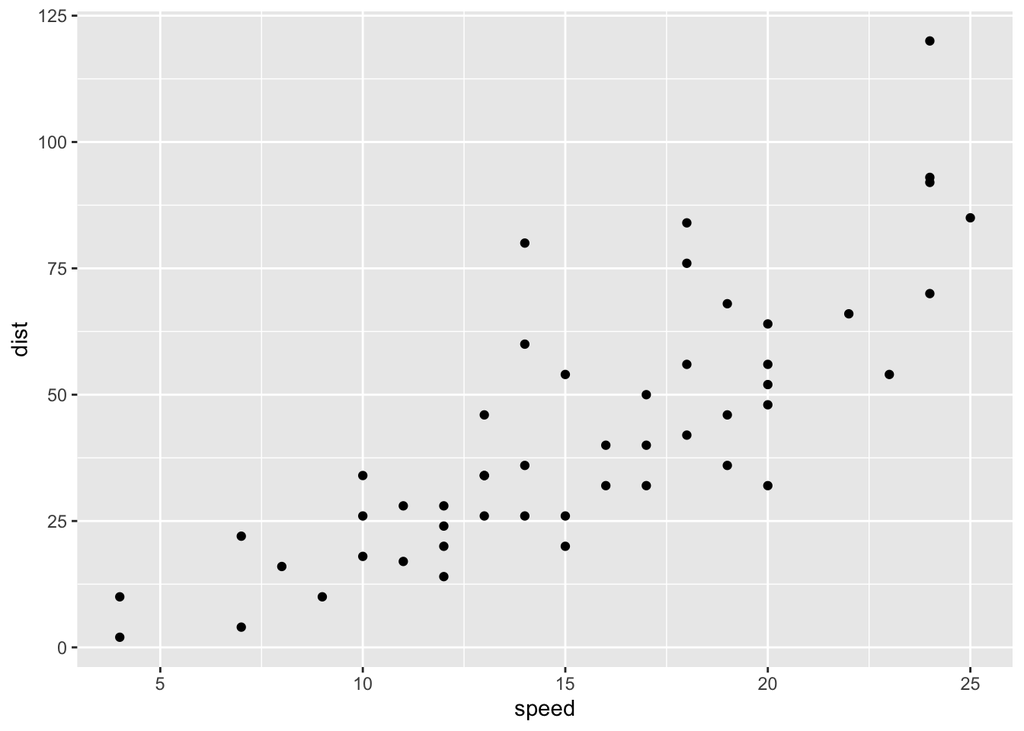

```r
cars %>% ggplot(aes(x=speed, y=dist)) +
  geom_point()
```

Crear el gráfico anterior coloreados en rojo los puntos.

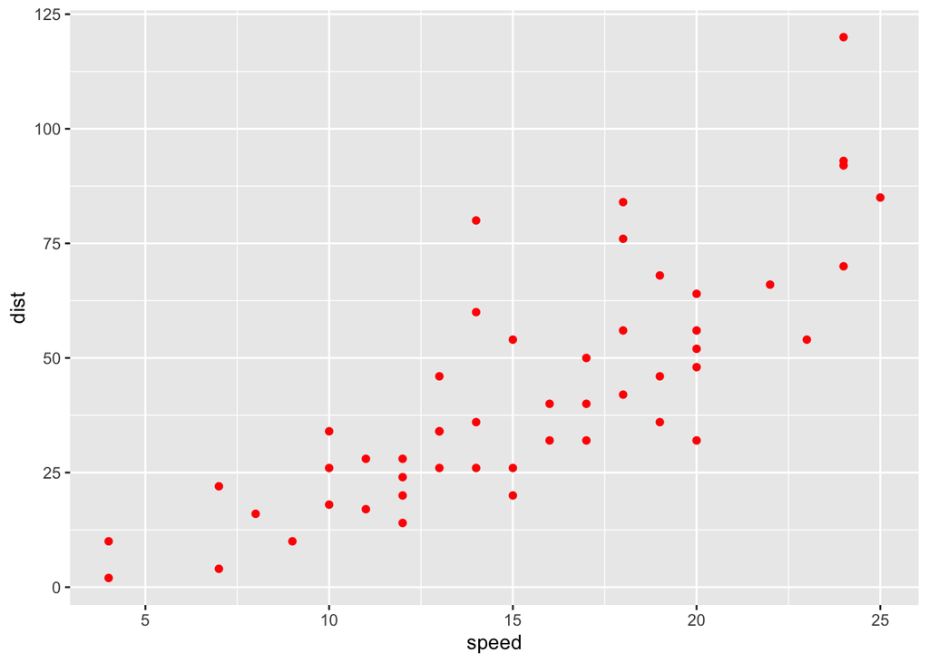

```r
cars %>% ggplot(aes(x=speed, y=dist)) +
  geom_point(colour="red")
```

Crear el gráfico anterior pero en este caso en función de la velocidad.

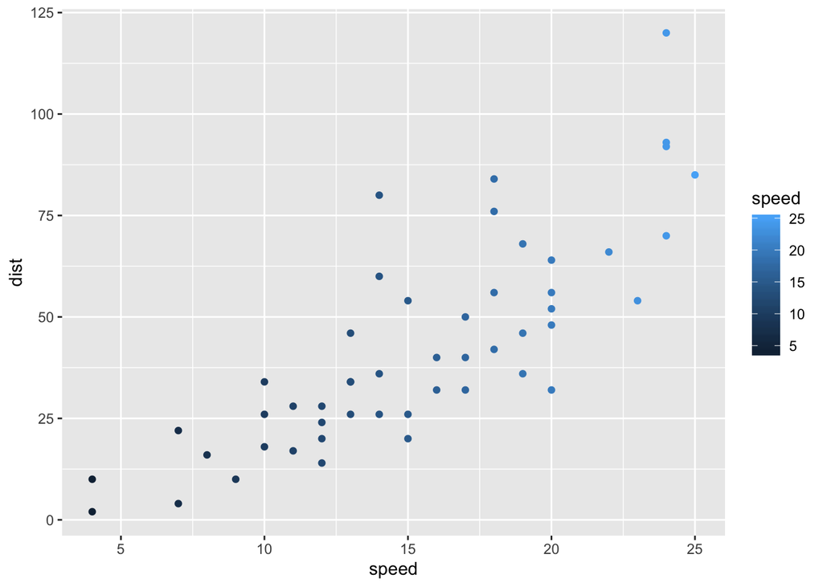

```r
cars %>% ggplot(aes(x=speed, y=dist,colour=speed)) +
  geom_point()
```

Crear el gráfico anterior pero en este caso en función de la distancia de frenado.

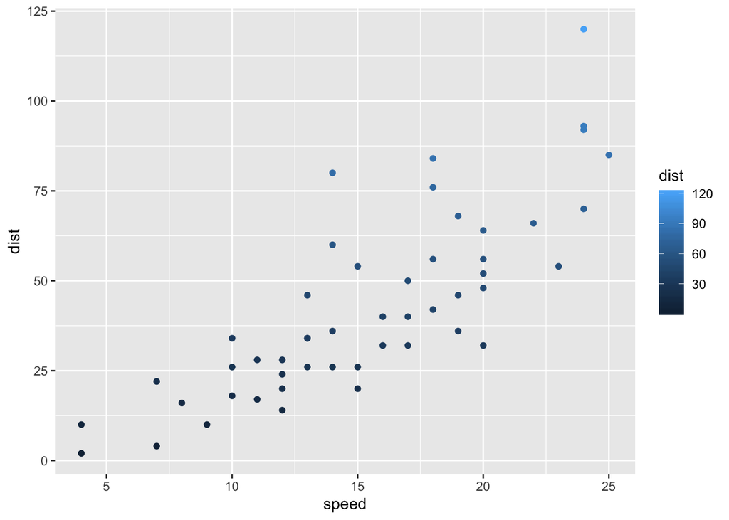

```r
cars %>% ggplot(aes(x=speed, y=dist, colour=dist)) +
  geom_point()
```

Introducir un modelo lineal (“lm”) mediante la función “geom_smooth” en el diagrama anterior y añadir un título descriptivo y nombres a los ejes x e y

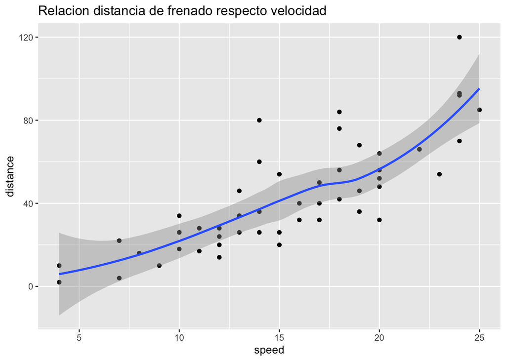

```r
cars %>% ggplot(aes(speed, dist)) +
  geom_point() +
  geom_smooth() +
  labs(x = "speed", y = "distance", title="Relacion distancia de frenado respecto velocidad")
```

## Ejercicio 2

Comprobar que tipo de datos tiene el conjunto de elementos proporcionado mediante la función “head”.

```r
head(airquality)
```

```
##   Ozone Solar.R Wind Temp Month Day
## 1    41     190  7.4   67     5   1
## 2    36     118  8.0   72     5   2
## 3    12     149 12.6   74     5   3
## 4    18     313 11.5   62     5   4
## 5    NA      NA 14.3   56     5   5
## 6    28      NA 14.9   66     5   6
```

Realizar un resumen para obtener información detalla del conjunto de elementos mediante la función “summary”.

```r
summary(airquality)
```

```
##      Ozone           Solar.R           Wind             Temp
##  Min.   :  1.00   Min.   :  7.0   Min.   : 1.700   Min.   :56.00
##  1st Qu.: 18.00   1st Qu.:115.8   1st Qu.: 7.400   1st Qu.:72.00
##  Median : 31.50   Median :205.0   Median : 9.700   Median :79.00
##  Mean   : 42.13   Mean   :185.9   Mean   : 9.958   Mean   :77.88
##  3rd Qu.: 63.25   3rd Qu.:258.8   3rd Qu.:11.500   3rd Qu.:85.00
##  Max.   :168.00   Max.   :334.0   Max.   :20.700   Max.   :97.00
##  NA's   :37       NA's   :7
##      Month            Day
##  Min.   :5.000   Min.   : 1.0
##  1st Qu.:6.000   1st Qu.: 8.0
##  Median :7.000   Median :16.0
##  Mean   :6.993   Mean   :15.8
##  3rd Qu.:8.000   3rd Qu.:23.0
##  Max.   :9.000   Max.   :31.0
##
```

Realiza la visualización de los datos. Para ello se debe crear un histograma (ggplot2) mediante “geom_bar”. Añadir el modelo lineal (“lm”) mediante “geom_smooth”.

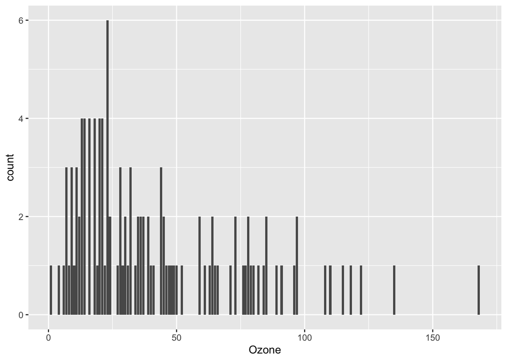

```r
# Variable Ozone
airquality %>%
  ggplot(aes(Ozone)) +
  geom_bar()
```

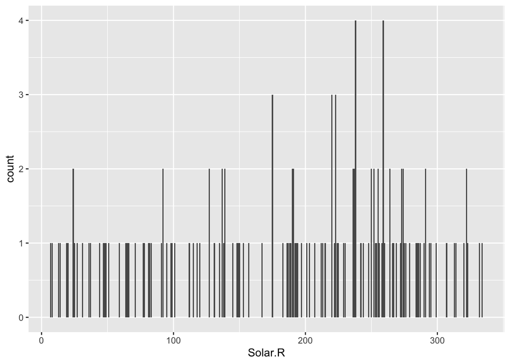

```r
# Variable Radiacion Solar
airquality %>%
  ggplot(aes(Solar.R)) +
  geom_bar()
```

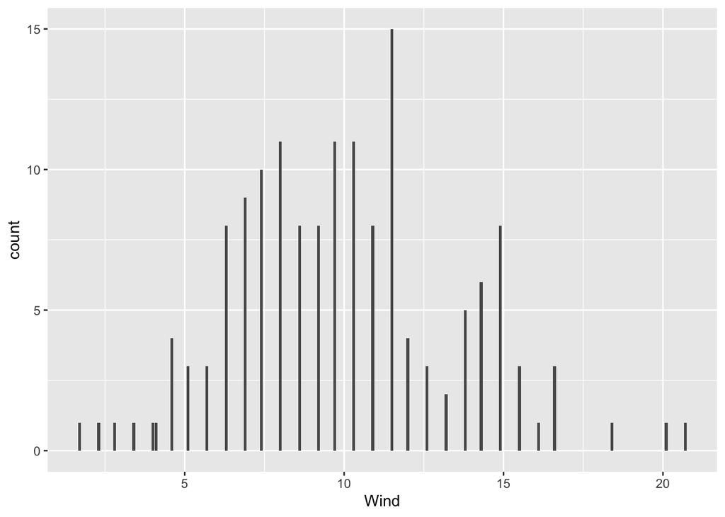

```r
# Variable Viento
airquality %>%
  ggplot(aes(Wind)) +
  geom_bar()
```

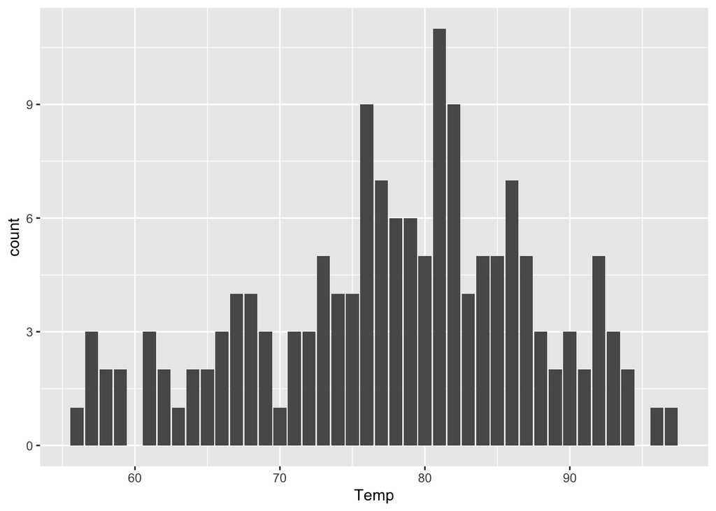

```r
# Variable Temperatura
airquality %>%
  ggplot(aes(Temp)) +
  geom_bar()
```

Crear un gráfico compuesto por los cuatro gráficos anteriores. Utilizar la librería “cowplot” y la función “plot_grid”.

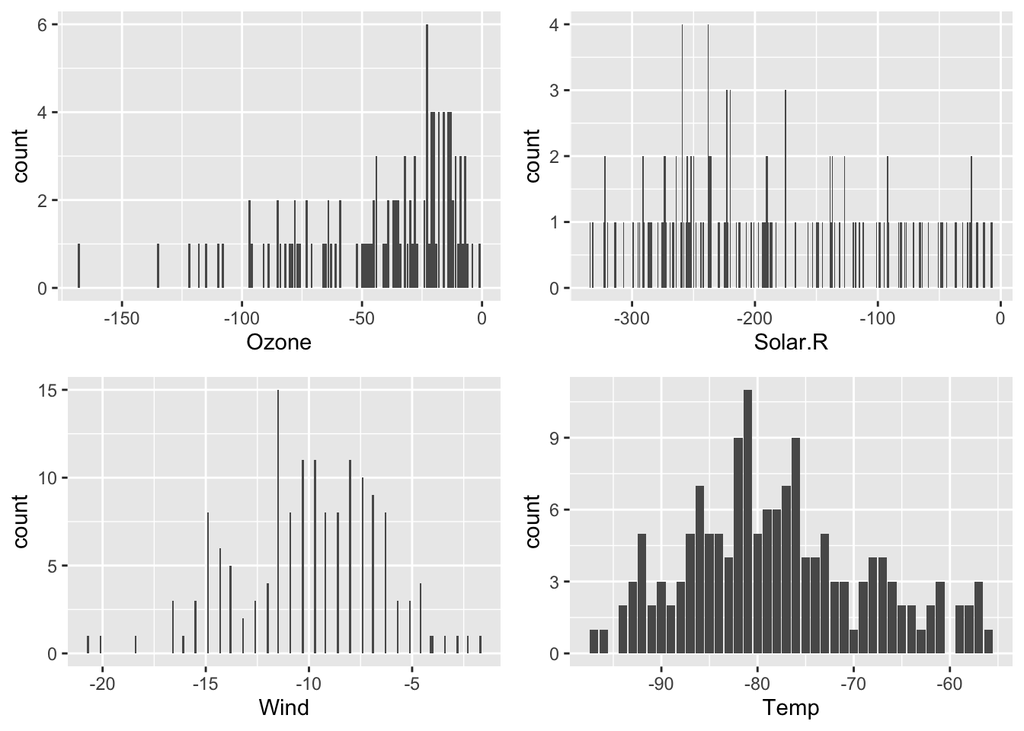

```r
p1 <-- airquality %>% ggplot(aes(Ozone)) + geom_bar()
p2 <-- airquality %>% ggplot(aes(Solar.R)) + geom_bar()
p3 <-- airquality %>% ggplot(aes(Wind)) + geom_bar()
p4 <-- airquality %>% ggplot(aes(Temp)) + geom_bar()
plot_grid(p1, p2, p3, p4)
```

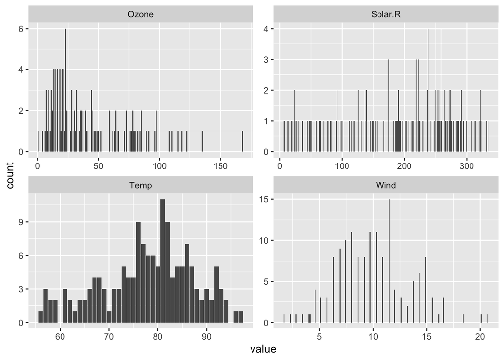

```r
# otra forma
airquality %>% select(1:4) %>%
  gather() %>%
  ggplot(aes(value)) +
  facet_wrap(~ key, scales = "free") +
  geom_bar()
```

De manera análoga al gráfico anterior crear un gráfico compuesto por las cuatro densidades de cada variable. Utilizar la función “geom_density”.

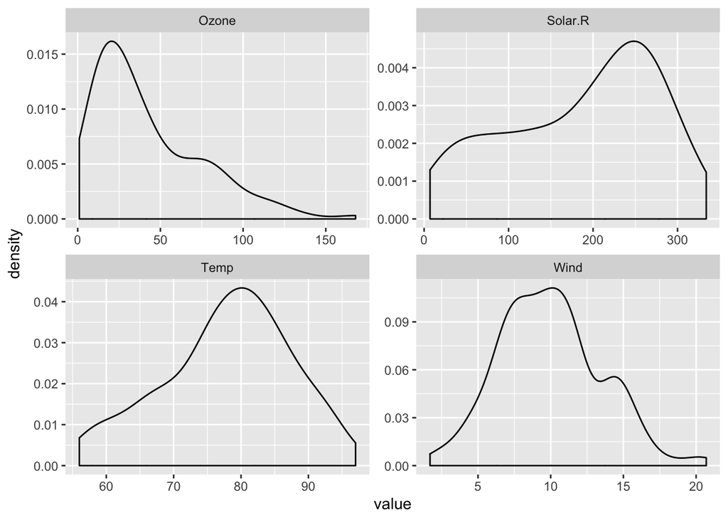

```r
airquality %>% select(1:4) %>%
  gather() %>%
  ggplot(aes(value)) +
  facet_wrap(~ key, scales = "free") +
  geom_density()
```

Indicar opinión sobre las variables según lo visualizado.

Las variables Ozono y Solar.R son asimétricas y será necesario realizar alguna transformación para poder hacerla mas simétrica Las variables Temp y Wind tienen una distribución mas normal. En base a esto se debería analizar la correlación. entre ellas, pero se puede observar que la concentración de ozono y la radiación solar deben tener alguna correlación. Igual que la concentración de ozono y la temperatura.

## Comentarios

En el ejercicio 2 a la hora de realizar la visualización de los datos con el modelo lineal geom_smooth no pude ser capaz de realizarlo. No se si el enunciado es correcto

Podria realizarse en base a la variable Ozone

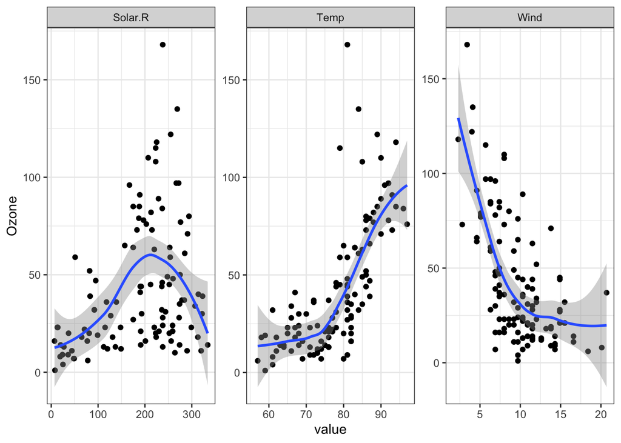

```r
airquality %>% select(1:4) %>%
  gather(-Ozone, key = "var", value = "value") %>%
  ggplot(aes(x = value, y = Ozone)) +
  geom_point() +
  stat_smooth() +
  facet_wrap(~ var, scales = "free") +
  theme_bw()
```